# Data Integration and Team Science

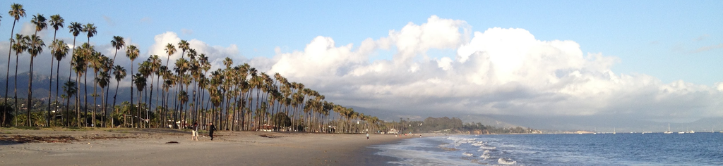

# Welcome

Welcome to [CRESCYNT](https://www.earthcube.org/group/crescynt-coral-reef-science-cyberinfrastructure-network)’s [**Data Science for Coral Reefs Workshop 2: Data Integration and Team Science**](http://crescyntblog.org/2017/12/22/crescynt-workshop-2-data-integration-and-team-science), hosted at [NCEAS](https://nceas.ucsb.edu/) in Santa Barbara, California, from March 12-15, 2018.

This training workshop will introduce you to open data science so you can work with data in an open, reproducible, and collaborative way. Open data science means that methods, data, and code are available so that others can access, reuse, and build from it without much fuss. Here you will learn a workflow with R, RStudio, Git, and GitHub, as recently described in [Lowndes *et al.* 2017, *Nature Ecology & Evolution*](https://www.nature.com/articles/s41559-017-0160).

This workshop is going to be fun, because learning these open data science tools and practices is empowering! We will live-code as we teach, with you doing everything hands-on on your own computer as you learn. [Our training materials](http://ohi-science.org/data-science-training/) that we use to teach are online and available for you as a reference. It can also be used as self-paced learning, or you can use it to teach an in-person workshop, as we have done with [Software Carpentry](https://jules32.github.io/2017-11-30-MBARI/).

## Workshop schedule

| time | Day 1 | Day 2 | Day 3 | Day 4 |
| --- | --- | --- | --- | --- |
| 9-10:30 | Welcome and goals of the workshop (CRESCYNT); Motivation for data science and coral reefs (NCEAS) | [Data wrangling: `dplyr`](http://ohi-science.org/data-science-training/dplyr.html#dplyr) (NCEAS) | Kaneohe Bay Workathon (all day) | Kaneohe Bay Workathon (all day) |
| break |  |  |  |  |
| 11-12:30 | [R, RStudio & RMarkdown](http://ohi-science.org/data-science-training/rstudio.html#rstudio) (NCEAS) | [Data wrangling: `tidyr`](http://ohi-science.org/data-science-training/tidyr) (NCEAS) |  |  |
| lunch |  |  |  |  |
| 13:00-14:30 | [RStudio+GitHub+RMarkdown](http://ohi-science.org/data-science-training/rstudio-github.html) (NCEAS) | [Programming in R](http://ohi-science.org/data-science-training/programming.html) (NCEAS) | Imagery/ interpolation breakout group (CRESCYNT) | Group Discussion/ Wrapup |
| break |  |  |  |  |
| 15:00-16:30 | [Visualization (ggplot2)](http://ohi-science.org/data-science-training/viz) (NCEAS) | [Collaborating with GitHub](http://ohi-science.org/data-science-training/collaborating.html) (NCEAS) | Imagery/ interpolation breakout group (CRESCYNT) | Group Discussion/ Wrapup |

## Prerequisites

Before the training, please make sure you have done the following.

Have up-to-date versions of `R` and RStudio and have RStudio configured with Git/GitHub:

1. Download and install R: https://cloud.r-project.org
2. Download and install RStudio: http://www.rstudio.com/download
3. Create a GitHub account: https://github.com *Note! Shorter names that kind of identify you are better, and use your work email!*

[figure not shown]

[figure not shown]